# 03 描述性统计、可视化与 CAPM 回归

本 Notebook 基于清洗合并后的 CSV 数据进行分析，输出描述性统计表、图形和 CAPM 回归结果，并提供可直接阅读的文字解读。

```python
from pathlib import Path
import math
import os

import numpy as np
import pandas as pd
import matplotlib.pyplot as plt
import seaborn as sns
from scipy import stats
import statsmodels.api as sm

ROOT = Path.cwd()
OUTPUT = ROOT / "output"
OUTPUT.mkdir(exist_ok=True)

plt.rcParams["font.sans-serif"] = ["Microsoft YaHei", "SimHei", "Arial Unicode MS", "DejaVu Sans"]
plt.rcParams["axes.unicode_minus"] = False
sns.set_theme(style="whitegrid", font="Microsoft YaHei")

combined = pd.read_csv(ROOT / "data/combined/combined_data.csv")
combined["date"] = pd.to_datetime(combined["date"])
stock_info = pd.read_csv(ROOT / "data/stock_list.csv")
finance = pd.read_csv(ROOT / "data/finance/finance_ratios.csv")

combined.head()
```

|  | date | code | name | open | close | high | low | volume | amount | source | return | is_extreme | industry | hs300_close | hs300_return | zz500_close | zz500_return | month | cpi | m2 |
| --- | --- | --- | --- | --- | --- | --- | --- | --- | --- | --- | --- | --- | --- | --- | --- | --- | --- | --- | --- | --- |
| 0 | 2020-01-02 | 1 | 平安银行 | 2161.80 | 2189.30 | 2199.30 | 2149.29 | 1530232.0 | 2.571196e+09 | akshare | NaN | False | 银行 | 4152.241 | NaN | 5366.138 | NaN | 2020-01 | 4.5 | 8.7 |
| 1 | 2020-01-03 | 1 | 平安银行 | 2198.05 | 2228.06 | 2244.31 | 2195.55 | 1116195.0 | 1.914495e+09 | akshare | 0.017549 | False | 银行 | 4144.965 | -0.001754 | 5380.637 | 0.002698 | 2020-01 | 4.5 | 8.7 |
| 2 | 2020-01-06 | 1 | 平安银行 | 2206.80 | 2214.31 | 2248.06 | 2194.30 | 862084.0 | 1.477930e+09 | akshare | -0.006190 | False | 银行 | 4129.295 | -0.003788 | 5434.850 | 0.010025 | 2020-01 | 4.5 | 8.7 |
| 3 | 2020-01-07 | 1 | 平安银行 | 2221.81 | 2224.31 | 2240.56 | 2199.30 | 728608.0 | 1.247047e+09 | akshare | 0.004506 | False | 银行 | 4160.227 | 0.007463 | 5499.840 | 0.011887 | 2020-01 | 4.5 | 8.7 |
| 4 | 2020-01-08 | 1 | 平安银行 | 2205.55 | 2163.05 | 2211.80 | 2159.30 | 847824.0 | 1.423609e+09 | akshare | -0.027927 | False | 银行 | 4112.317 | -0.011583 | 5423.797 | -0.013923 | 2020-01 | 4.5 | 8.7 |

## 4.1 基本统计量

日收益率使用对数收益率，年化均值乘以 252，年化波动率乘以 `sqrt(252)`，最大回撤基于累计净值计算。

```python
def max_drawdown(ret: pd.Series) -> float:
    wealth = np.exp(ret.fillna(0).cumsum())
    drawdown = wealth / wealth.cummax() - 1
    return drawdown.min()


stats_records = []
for code_value, group in combined.sort_values("date").groupby("code"):
    ret = group["return"].dropna()
    meta = stock_info.loc[stock_info["code"].astype(str).str.zfill(6) == str(code_value).zfill(6)].iloc[0]
    stats_records.append({
        "股票": meta["name"],
        "代码": str(code_value).zfill(6),
        "行业": meta["industry"],
        "年化均值": ret.mean() * 252,
        "年化波动率": ret.std() * math.sqrt(252),
        "偏度": ret.skew(),
        "峰度": ret.kurt(),
        "最大回撤": max_drawdown(ret),
    })

desc_stats = pd.DataFrame(stats_records)
desc_stats.to_csv(ROOT / "output/descriptive_stats.csv", index=False, encoding="utf-8-sig")
desc_stats
```

|  | 股票 | 代码 | 行业 | 年化均值 | 年化波动率 | 偏度 | 峰度 | 最大回撤 |
| --- | --- | --- | --- | --- | --- | --- | --- | --- |
| 0 | 平安银行 | 000001 | 银行 | -0.036791 | 0.265626 | 0.366956 | 4.588470 | -0.593755 |
| 1 | 中兴通讯 | 000063 | 通讯 | 0.018865 | 0.425718 | 0.309410 | 2.445436 | -0.618668 |
| 2 | 五粮液 | 000858 | 白酒 | -0.027287 | 0.315906 | 0.007888 | 3.399582 | -0.666227 |
| 3 | 比亚迪 | 002594 | 汽车 | 0.298240 | 0.431090 | 0.308524 | 2.105598 | -0.525353 |
| 4 | 招商银行 | 600036 | 银行 | 0.032078 | 0.231882 | 0.261592 | 3.564639 | -0.453004 |
| 5 | 贵州茅台 | 600519 | 白酒 | 0.049910 | 0.255815 | 0.199471 | 3.538868 | -0.451789 |
| 6 | 长江电力 | 600900 | 能源 | 0.097153 | 0.178075 | 0.365532 | 3.531617 | -0.175399 |
| 7 | 中国移动 | 600941 | 通讯 | 0.171986 | 0.249081 | 0.606050 | 5.035782 | -0.192001 |
| 8 | 长城汽车 | 601633 | 汽车 | 0.134685 | 0.448674 | 0.458536 | 2.194462 | -0.706053 |
| 9 | 中国石油 | 601857 | 能源 | 0.157906 | 0.292828 | 0.206582 | 5.083190 | -0.325359 |

统计表显示，10 只股票的收益风险差异非常明显。比亚迪年化均值最高，达到 29.82%，但年化波动率也高达 43.11%，属于高收益、高波动的成长型样本；中国移动、中国石油和长城汽车的年化均值也较高，分别约为 17.20%、15.79% 和 13.47%。平安银行和五粮液的年化均值为负，说明样本期内价格修复不足。最大回撤方面，长城汽车、五粮液、中兴通讯和平安银行分别出现约 -70.61%、-66.62%、-61.87% 和 -59.38% 的深度回撤，而长江电力和中国移动的最大回撤仅约 -17.54% 和 -19.20%，防御属性更强。

## 图 1：归一化收盘价走势图

将每个资产的起点标准化为 1，可以比较不同价格水平股票的相对走势。

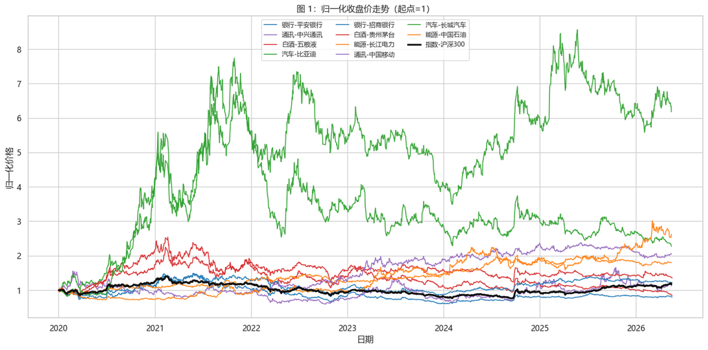

```python
industry_palette = {
    "银行": "#1f77b4", "白酒": "#d62728", "汽车": "#2ca02c",
    "能源": "#ff7f0e", "通讯": "#9467bd", "指数": "#111111",
}

price_wide = combined.pivot_table(index="date", columns="code", values="close", aggfunc="last").sort_index()
norm_prices = price_wide / price_wide.apply(lambda s: s.dropna().iloc[0])
hs300 = combined.drop_duplicates("date").set_index("date")["hs300_close"].sort_index()
hs300_norm = hs300 / hs300.dropna().iloc[0]

fig, ax = plt.subplots(figsize=(14, 7))
for code_value in norm_prices.columns:
    meta = stock_info.loc[stock_info["code"].astype(str).str.zfill(6) == str(code_value).zfill(6)].iloc[0]
    ax.plot(norm_prices.index, norm_prices[code_value], lw=1.3, alpha=0.9, color=industry_palette[meta["industry"]], label=f"{meta['industry']}-{meta['name']}")
ax.plot(hs300_norm.index, hs300_norm, color=industry_palette["指数"], lw=2.5, label="指数-沪深300")
ax.set_title("图 1：归一化收盘价走势（起点=1）")
ax.set_xlabel("日期")
ax.set_ylabel("归一化价格")
ax.legend(ncol=3, fontsize=9)
fig.tight_layout()
fig.savefig(OUTPUT / "fig1_normalized_prices.png", dpi=180)
plt.show()
```

图 1 可以看出，样本期内个股走势明显分化。比亚迪的归一化收盘价最终约为起点的 6.18 倍，是 10 只股票中表现最突出的样本，但过程波动也较大；中国石油、长城汽车、中国移动和长江电力最终分别约为起点的 2.62 倍、2.28 倍、2.05 倍和 1.80 倍，明显强于沪深 300 约 1.17 倍的同期表现。相反，五粮液和平安银行期末仍低于起点，分别约为 0.85 倍和 0.80 倍，说明白酒和银行中的部分样本在 2020 年以来承受了较长时间的估值或基本面压力。

## 图 2：日收益率分布图

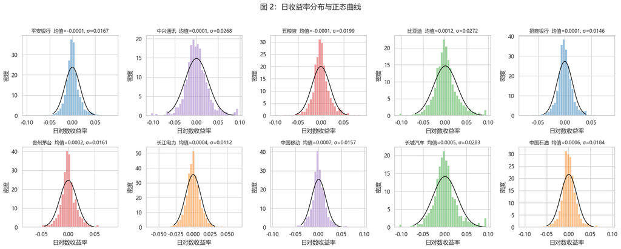

```python
fig, axes = plt.subplots(2, 5, figsize=(18, 7), sharex=False, sharey=False)
for ax, (code_value, group) in zip(axes.ravel(), combined.groupby("code")):
    meta = stock_info.loc[stock_info["code"].astype(str).str.zfill(6) == str(code_value).zfill(6)].iloc[0]
    ret = group["return"].dropna()
    sns.histplot(ret, bins=40, stat="density", color=industry_palette[meta["industry"]], alpha=0.45, ax=ax)
    x = np.linspace(ret.quantile(0.01), ret.quantile(0.99), 200)
    ax.plot(x, stats.norm.pdf(x, ret.mean(), ret.std()), color="black", lw=1.2)
    ax.set_title(f"{meta['name']}  均值={ret.mean():.4f}, σ={ret.std():.4f}", fontsize=10)
    ax.set_xlabel("日对数收益率")
    ax.set_ylabel("密度")
fig.suptitle("图 2：日收益率分布与正态曲线", y=1.02, fontsize=15)
fig.tight_layout()
fig.savefig(OUTPUT / "fig2_return_distribution.png", dpi=180, bbox_inches="tight")
plt.show()
```

图 2 与描述性统计共同说明，10 只股票的日收益率并不完全符合简单正态分布。所有股票偏度均为正，其中中国移动偏度约 0.61、长城汽车约 0.46，说明右尾收益更突出；峰度方面，中国石油、中国移动和平安银行分别约为 5.08、5.04 和 4.59，高于正态分布基准，体现出尖峰厚尾特征。也就是说，样本股票虽然多数交易日波动集中在 0 附近，但极端涨跌出现概率高于正态假设，风险评估不能只依赖均值和波动率。

## 图 3：收益率相关系数热力图

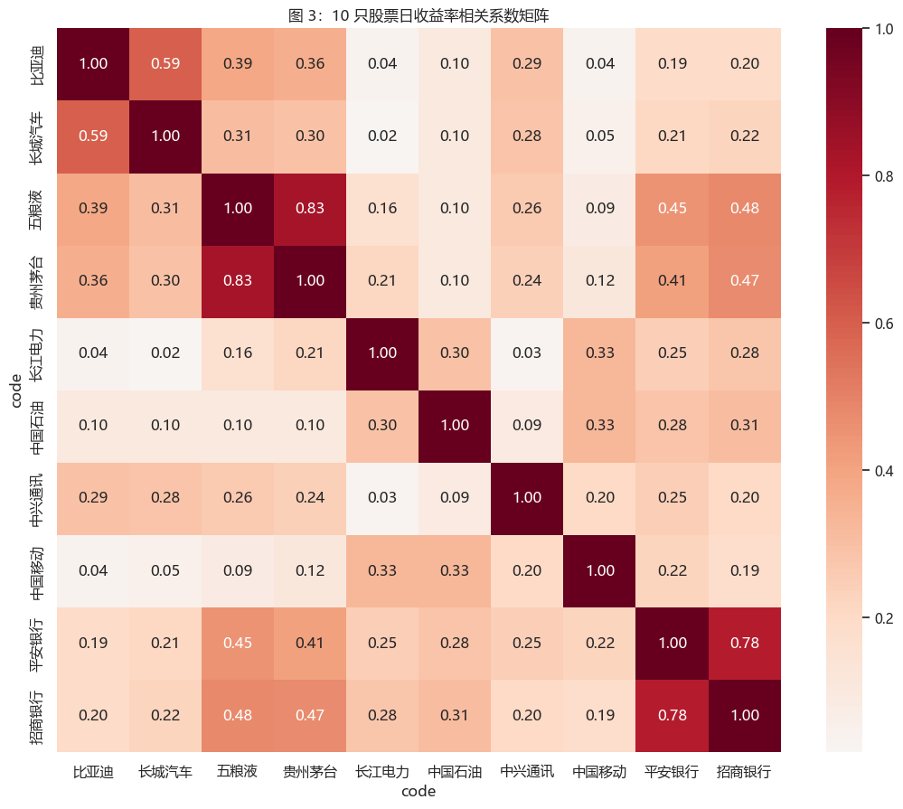

```python
ordered_codes = stock_info.sort_values(["industry", "code"])["code"].astype(str).str.zfill(6).tolist()
ret_wide = combined.pivot_table(index="date", columns="code", values="return", aggfunc="last")
ret_wide.columns = ret_wide.columns.astype(str).str.zfill(6)
corr = ret_wide[ordered_codes].corr()
labels = [stock_info.loc[stock_info["code"].astype(str).str.zfill(6) == c, "name"].iloc[0] for c in ordered_codes]

fig, ax = plt.subplots(figsize=(11, 9))
sns.heatmap(corr, cmap="RdBu_r", center=0, annot=True, fmt=".2f", square=True,
            xticklabels=labels, yticklabels=labels, ax=ax)
ax.set_title("图 3：10 只股票日收益率相关系数矩阵")
fig.tight_layout()
fig.savefig(OUTPUT / "fig3_return_correlation_heatmap.png", dpi=180)
plt.show()
```

图 3 显示行业内相关性具有明显差异。白酒组合五粮液与贵州茅台的相关系数约为 0.83，是样本中最高的一组；银行组合平安银行与招商银行约为 0.78，也体现出较强的行业共振。汽车组合比亚迪与长城汽车约为 0.59，相关性中等，说明二者同受汽车产业景气影响，但新能源转型、产品结构和公司自身事件仍会带来差异。通信组内部的中国移动与中兴通讯相关性较弱，主要因为前者偏运营商和高股息属性，后者偏设备制造和技术周期属性。

## 图 4：宏观指标与股市关系

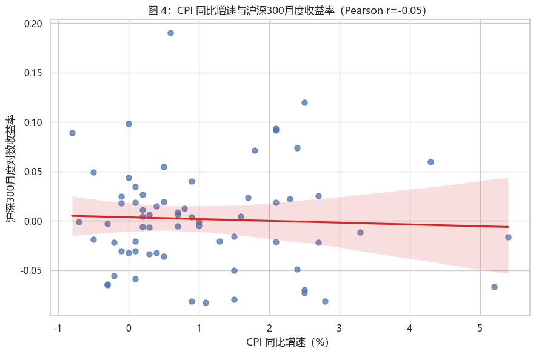

```python
monthly = (
    combined.drop_duplicates("date")
    .set_index("date")
    .sort_index()[["hs300_close", "cpi", "m2"]]
    .resample("ME")
    .last()
)
monthly["hs300_monthly_return"] = np.log(monthly["hs300_close"] / monthly["hs300_close"].shift(1))
scatter = monthly.dropna(subset=["hs300_monthly_return", "cpi"])
pearson_r = scatter["cpi"].corr(scatter["hs300_monthly_return"])

fig, ax = plt.subplots(figsize=(9, 6))
sns.regplot(data=scatter, x="cpi", y="hs300_monthly_return", ax=ax,
            scatter_kws={"s": 42, "alpha": 0.75}, line_kws={"color": "#d62728"})
ax.set_title(f"图 4：CPI 同比增速与沪深300月度收益率（Pearson r={pearson_r:.2f}）")
ax.set_xlabel("CPI 同比增速（%）")
ax.set_ylabel("沪深300月度对数收益率")
fig.tight_layout()
fig.savefig(OUTPUT / "fig4_macro_cpi_vs_hs300.png", dpi=180)
plt.show()
```

图 4 中 CPI 同比增速与沪深 300 月度收益率的 Pearson 相关系数约为 -0.05，M2 同比增速与沪深 300 月度收益率的相关系数也约为 -0.05，均接近 0。这说明在 2020 年以来的样本中，单独使用 CPI 或 M2 难以解释沪深 300 的短期月度收益变化。宏观变量仍然重要，但它们通常通过政策预期、盈利周期、流动性和风险偏好共同作用于市场，不能从单变量线性关系直接推出投资结论。

## 图 5（选做）：财务指标 ROE 跨公司对比

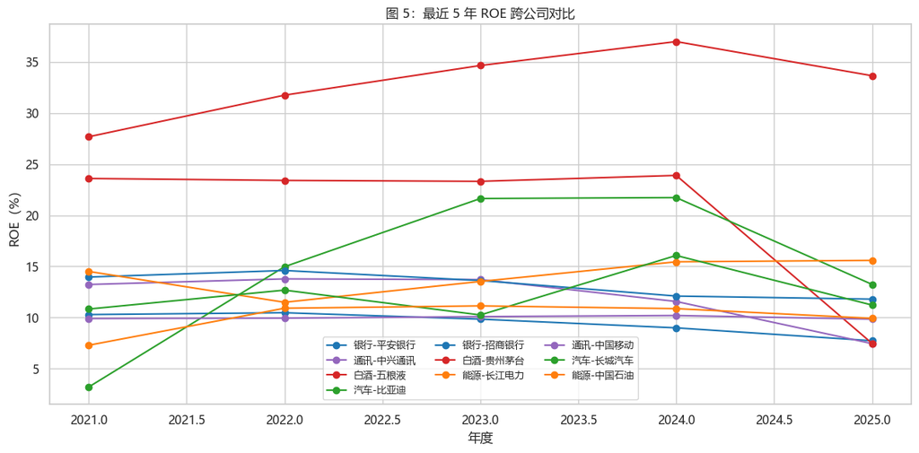

```python
roe = finance[finance["indicator"] == "roe"].copy()
fig, ax = plt.subplots(figsize=(12, 6))
for code_value, group in roe.groupby("code"):
    meta = stock_info.loc[stock_info["code"].astype(str).str.zfill(6) == str(code_value).zfill(6)].iloc[0]
    ax.plot(group["year"], group["value"], marker="o", color=industry_palette[meta["industry"]], label=f"{meta['industry']}-{meta['name']}")
ax.set_title("图 5：最近 5 年 ROE 跨公司对比")
ax.set_xlabel("年度")
ax.set_ylabel("ROE（%）")
ax.legend(ncol=3, fontsize=9)
fig.tight_layout()
fig.savefig(OUTPUT / "fig5_roe_comparison.png", dpi=180)
plt.show()
```

图 5 的 ROE 对比显示，贵州茅台在最近 5 年保持明显领先，平均 ROE 约 32.94%，2025 年仍有 33.65%，盈利能力和资本回报质量最突出。五粮液 5 年平均 ROE 约 20.34%，但 2025 年降至 7.47%，与其股价表现承压相互印证。银行中招商银行平均 ROE 约 13.22%，高于平安银行的 9.46%；能源中长江电力平均 ROE 约 14.11%，且 2025 年达到 15.59%，与其较低波动和较小回撤形成一致的稳健特征。汽车和通讯样本中，比亚迪、长城汽车、中兴通讯的 ROE 有一定波动，说明成长行业的盈利质量更容易受到产业周期和投入扩张影响。

## 5.1 CAPM 模型估计

CAPM 设定无风险利率为年化 2%，换算为日度 `0.02 / 252`。

```python
RF_DAILY = 0.02 / 252
capm_records = []

for code_value, group in combined.groupby("code"):
    data = group[["return", "hs300_return"]].dropna().copy()
    data["excess_stock"] = data["return"] - RF_DAILY
    data["excess_market"] = data["hs300_return"] - RF_DAILY
    X = sm.add_constant(data["excess_market"])
    y = data["excess_stock"]
    model = sm.OLS(y, X).fit()
    ci = model.conf_int().loc["excess_market"]
    meta = stock_info.loc[stock_info["code"].astype(str).str.zfill(6) == str(code_value).zfill(6)].iloc[0]
    capm_records.append({
        "股票": meta["name"],
        "代码": str(code_value).zfill(6),
        "行业": meta["industry"],
        "alpha": model.params["const"],
        "alpha_pvalue": model.pvalues["const"],
        "beta": model.params["excess_market"],
        "beta_ci_low": ci[0],
        "beta_ci_high": ci[1],
        "r_squared": model.rsquared,
    })

capm_results = pd.DataFrame(capm_records).sort_values("beta", ascending=False)
capm_results.to_csv(OUTPUT / "capm_results.csv", index=False, encoding="utf-8-sig")
capm_results
```

|  | 股票 | 代码 | 行业 | alpha | alpha_pvalue | beta | beta_ci_low | beta_ci_high | r_squared |
| --- | --- | --- | --- | --- | --- | --- | --- | --- | --- |
| 3 | 比亚迪 | 002594 | 汽车 | 0.001075 | 0.061908 | 1.274606 | 1.179361 | 1.369851 | 0.309537 |
| 1 | 中兴通讯 | 000063 | 通讯 | -0.000040 | 0.943441 | 1.247095 | 1.152636 | 1.341554 | 0.303922 |
| 8 | 长城汽车 | 601633 | 汽车 | 0.000428 | 0.494764 | 1.175152 | 1.071348 | 1.278956 | 0.242898 |
| 2 | 五粮液 | 000858 | 白酒 | -0.000210 | 0.564835 | 1.168443 | 1.108095 | 1.228792 | 0.484114 |
| 5 | 贵州茅台 | 600519 | 白酒 | 0.000102 | 0.741366 | 0.893367 | 0.842071 | 0.944664 | 0.431581 |
| 0 | 平安银行 | 000001 | 银行 | -0.000239 | 0.480727 | 0.855568 | 0.799370 | 0.911767 | 0.367159 |
| 4 | 招商银行 | 600036 | 银行 | 0.000033 | 0.911587 | 0.748917 | 0.699930 | 0.797904 | 0.369114 |
| 9 | 中国石油 | 601857 | 能源 | 0.000537 | 0.233522 | 0.446139 | 0.371546 | 0.520731 | 0.082188 |
| 7 | 中国移动 | 600941 | 通讯 | 0.000627 | 0.184968 | 0.298104 | 0.215344 | 0.380864 | 0.045417 |
| 6 | 长江电力 | 600900 | 能源 | 0.000308 | 0.269781 | 0.224457 | 0.178387 | 0.270528 | 0.056470 |

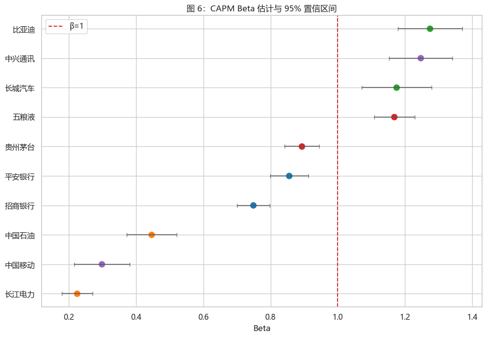

```python
fig, ax = plt.subplots(figsize=(10, 7))
plot_df = capm_results.sort_values("beta")
y_pos = np.arange(len(plot_df))
colors = plot_df["行业"].map(industry_palette)
xerr = np.vstack([
    plot_df["beta"] - plot_df["beta_ci_low"],
    plot_df["beta_ci_high"] - plot_df["beta"],
])
ax.errorbar(plot_df["beta"], y_pos, xerr=xerr, fmt="none", ecolor="#555555", capsize=3, alpha=0.8)
ax.scatter(plot_df["beta"], y_pos, c=colors, s=70)
ax.axvline(1.0, color="#d62728", linestyle="--", lw=1.4, label="β=1")
ax.set_yticks(y_pos)
ax.set_yticklabels(plot_df["股票"])
ax.set_xlabel("Beta")
ax.set_title("图 6：CAPM Beta 估计与 95% 置信区间")
ax.legend()
fig.tight_layout()
fig.savefig(OUTPUT / "fig6_capm_beta.png", dpi=180)
plt.show()
```

### CAPM 讨论

```python
beta_gt_1 = capm_results[capm_results["beta"] > 1].sort_values("beta", ascending=False)
beta_low = capm_results[capm_results["beta"] < 0.5].sort_values("beta")
alpha_sig_5 = capm_results[capm_results["alpha_pvalue"] < 0.05]
alpha_sig_10 = capm_results[capm_results["alpha_pvalue"] < 0.10]
highest_r2 = capm_results.loc[capm_results["r_squared"].idxmax()]
lowest_r2 = capm_results.loc[capm_results["r_squared"].idxmin()]

print("1. 哪些股票的 Beta 更高，说明系统性风险更强？")
print("   Beta 大于 1 的股票包括：" + "、".join([f"{r['股票']}（{r['行业']}，β={r['beta']:.2f}）" for _, r in beta_gt_1.iterrows()]) + "。")
print("   其中比亚迪、中兴通讯、长城汽车和五粮液对沪深 300 的市场波动更敏感，市场上涨时可能放大收益，市场下跌时也更容易放大亏损。")
print("   Beta 低于 0.5 的股票包括：" + "、".join([f"{r['股票']}（{r['行业']}，β={r['beta']:.2f}）" for _, r in beta_low.iterrows()]) + "。长江电力、中国移动和中国石油的系统性风险暴露较低，更接近防御或高股息资产特征。")

print("\n2. Alpha 是否显著，能否说明有稳定超额收益？")
if alpha_sig_5.empty:
    print("   在 5% 显著性水平下，没有股票的 Alpha 显著异于 0，说明控制沪深 300 市场风险后，本样本未发现稳定、统计显著的日均超额收益。")
else:
    print("   5% 水平显著的 Alpha 股票为：" + "、".join([f"{r['股票']}（p={r['alpha_pvalue']:.3f}）" for _, r in alpha_sig_5.iterrows()]) + "。")
if not alpha_sig_10.empty:
    print("   如果放宽到 10% 水平，比亚迪的 Alpha 接近显著（p≈0.062），但仍不能作为确定性超额收益结论，只能说明样本期内存在较强成长收益特征。")

print("\n3. CAPM 对哪些股票解释力更强？")
print(f"   R² 最高的是 {highest_r2['股票']}（{highest_r2['r_squared']:.2%}），其次通常集中在白酒和银行样本，说明这些股票收益中有较大比例可由市场因子解释。")
print(f"   R² 最低的是 {lowest_r2['股票']}（{lowest_r2['r_squared']:.2%}），长江电力、中国移动、中国石油等低 Beta 股票的 R² 也偏低，说明其收益更多受到公司特质、股息预期、能源价格或行业监管等非市场单因子影响。")
```

```
1. 哪些股票的 Beta 更高，说明系统性风险更强？
   Beta 大于 1 的股票包括：比亚迪（汽车，β=1.27）、中兴通讯（通讯，β=1.25）、长城汽车（汽车，β=1.18）、五粮液（白酒，β=1.17）。
   其中比亚迪、中兴通讯、长城汽车和五粮液对沪深 300 的市场波动更敏感，市场上涨时可能放大收益，市场下跌时也更容易放大亏损。
   Beta 低于 0.5 的股票包括：长江电力（能源，β=0.22）、中国移动（通讯，β=0.30）、中国石油（能源，β=0.45）。长江电力、中国移动和中国石油的系统性风险暴露较低，更接近防御或高股息资产特征。

2. Alpha 是否显著，能否说明有稳定超额收益？
   在 5% 显著性水平下，没有股票的 Alpha 显著异于 0，说明控制沪深 300 市场风险后，本样本未发现稳定、统计显著的日均超额收益。
   如果放宽到 10% 水平，比亚迪的 Alpha 接近显著（p≈0.062），但仍不能作为确定性超额收益结论，只能说明样本期内存在较强成长收益特征。

3. CAPM 对哪些股票解释力更强？
   R² 最高的是 五粮液（48.41%），其次通常集中在白酒和银行样本，说明这些股票收益中有较大比例可由市场因子解释。
   R² 最低的是 中国移动（4.54%），长江电力、中国移动、中国石油等低 Beta 股票的 R² 也偏低，说明其收益更多受到公司特质、股息预期、能源价格或行业监管等非市场单因子影响。
```

## 结论

本项目基于 2020 年以来 10 只 A 股、沪深 300/中证 500、CPI/M2 和财务指标构建了完整的数据获取、清洗、存储和分析流程。数据层面，清洗后股票长表共有 14905 行，重复值和极端收益标注均已检查；Parquet 文件约 712 KB，小于 CSV 的约 1831 KB，当前测试中读取速度也更快，说明列式存储适合作为后续扩展方案。

投资表现层面，样本不是简单的行业平均差异，而是呈现出清晰的结构分化：比亚迪收益最高但波动较大，长江电力和中国移动回撤较小、防御属性更强，中国石油在样本期表现较好但 CAPM 解释力较弱，白酒内部贵州茅台盈利能力和股价韧性明显强于五粮液，银行内部招商银行表现优于平安银行。

风险解释层面，CAPM 结果显示高 Beta 股票主要集中在比亚迪、中兴通讯、长城汽车和五粮液，低 Beta 股票集中在长江电力、中国移动和中国石油；但 5% 水平下没有股票获得显著 Alpha，说明单靠本样本不能证明存在稳定超额收益。整体来看，CAPM 适合比较系统性风险暴露，但对低 Beta、高股息或强公司特质股票的解释力有限，实际分析仍需要结合行业周期、盈利能力和宏观环境。